# Rapport de projet IF36 : Counter-Strike 2

# III - Armes & dynamique des rounds

Nous passons maintenant au cœur mécanique du jeu : l’économie, le timing, l’arsenal et les situations de clutch. Ces analyses cherchent à comprendre ce qui décide réellement d’un round une fois l’action lancée : l’avantage durable du pistol round, le poids du premier kill, le moment où l’on tue selon l’arme, la viabilité du run and gun, et les chances de retourner une situation défavorable.

## Le pistol round confère-t-il un avantage durable ?

On cherche à savoir si gagner le pistol round (round 1) donne un avantage sur les rounds suivants. La théorie des joueurs est que le pistol round crée un avantage économique qui “snowball” sur les 2-3 rounds suivants grâce à l’argent gagné. On s’attend donc à voir le taux de victoire de l’équipe ayant gagné le pistol diminuer progressivement au fil des rounds jusqu’à revenir à 50%.

**Données utilisées** : table `rounds`, colonnes `match_checksum`, `number` et `winner_side`.

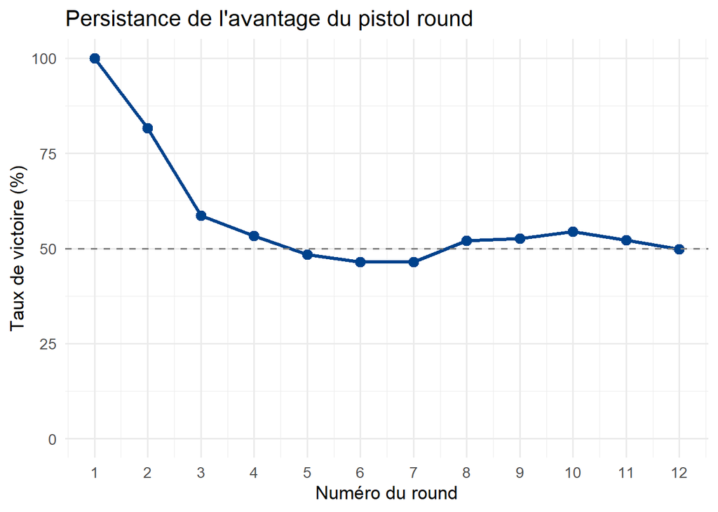

```sql
SELECT match_checksum, number, winner_side
FROM rounds
WHERE number BETWEEN 1 AND 12
```

## Quel côté (T ou CT) a un avantage structurel selon les cartes ?

On cherche à savoir si certaines cartes favorisent structurellement un camp par rapport à l’autre. On s’attend à trouver des asymétries selon les cartes, par exemple Inferno traditionnellement perçue comme favorable aux Terroristes.

**Données utilisées** : tables `rounds` et `demos`, colonnes `winner_side` et `map_name`.

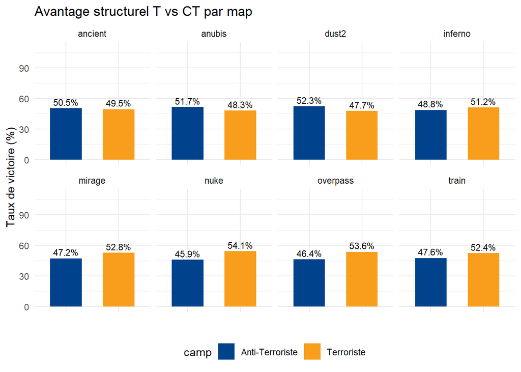

```sql
SELECT r.winner_side, d.map_name
FROM rounds r
JOIN demos d ON r.match_checksum = d.checksum
```

## Le premier kill d’un round est-il décisif ?

Pour ce graphique, on se demande si le premier kill d’un round est décisif, et donc s’il est important pour une équipe d’aller chercher cette première élimination à tout prix. Cela pourrait dire aussi que mourir bêtement en premier diminue de beaucoup les chances de gagner ce round. Le graphique suivant a donc été construit en comptant le nombre de fois où le side du gagnant de la manche est le même que le side du joueur qui a fait le premier kill, en rapportant cela au nombre total de manches :

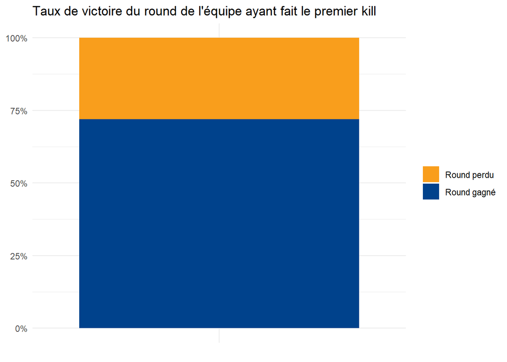

On voit donc bien qu’il y a presque 75% de manches où la manche a été gagnée par l’équipe du joueur ayant fait le premier kill. Cependant, un autre paramètre peut être pris en compte pour augmenter (ou diminuer) cette statistique, et c’est le type d’économie choisi par l’équipe ayant fait le premier kill de la manche en cours. En effet, si une équipe fait le premier kill mais qu’elle a choisi d’économiser sur ce round, alors il reste de bonnes chances qu’elle perde ce round quand même. Le prochain graphique contient donc les données du premier, mais en ne gardant que les rounds où le type d’économie est le même pour chaque équipe :

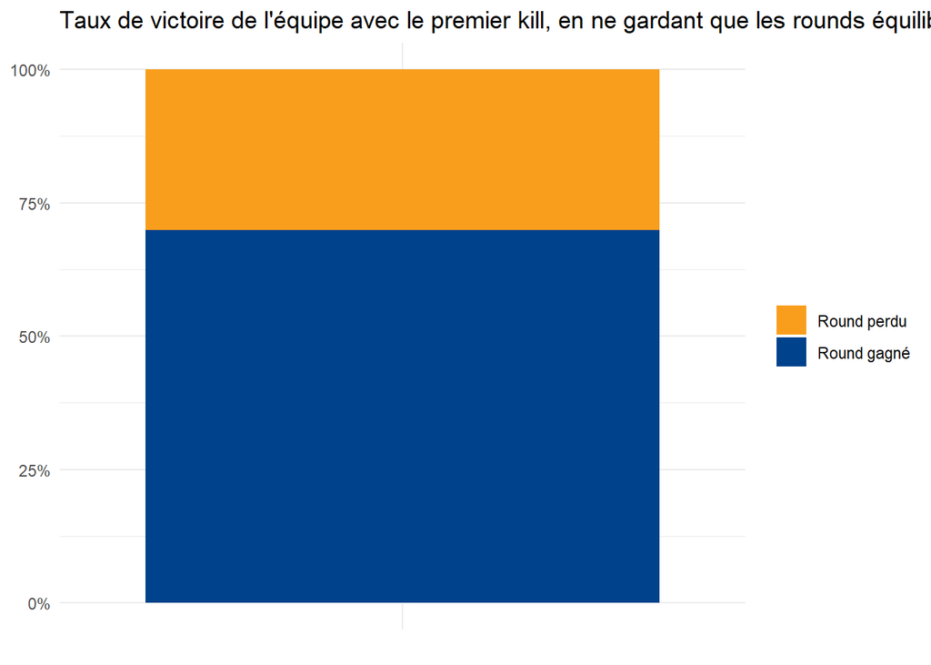

En retirant les rounds déséquilibrés, on obtient un résultat plus juste, et légèrement inférieur au premier graphique. Cependant, une visualisation de cette valeur cette fois-ci par round pourrait révéler une nouvelle tendance. On garde ici le dataset du précédent graphique :

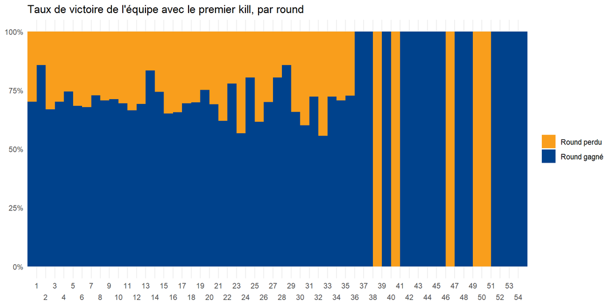

Une première observation qui peut être faite est qu’au deuxième round, l’équipe qui fait le premier kill a beaucoup de chances de gagner ce round. En effet, comme l’équipe qui a gagné le premier round possède désormais de meilleures armes, elle a plus de chances de tuer en premier un joueur, puis de gagner le round. Une autre observation est qu’à partir des rounds 20-21, l’écart type augmente, et donc prendre le premier kill peut augmenter de beaucoup les chances de gagner le round, mais cela peut aussi conférer un avantage moins important que normalement pour gagner le round.

## Quelles sont les armes les plus utilisées ?

Pour répondre à la question, nous allons d’abord nous intéresser à la répartition d’achat des armes sur CS. Ce premier graphique montre la répartition de ces achats pour 8 cartes.

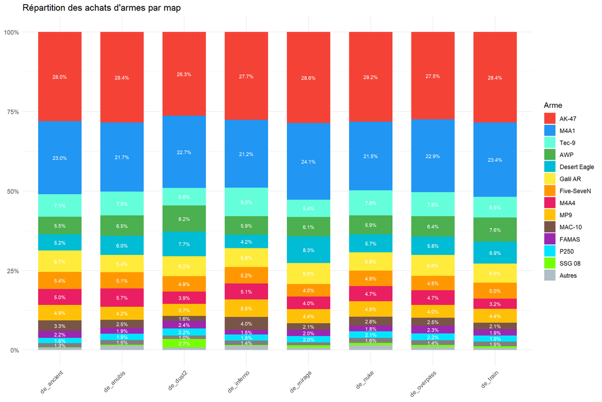

Deux armes se dégagent, l’AK-47 et la M4A1, avec une répartition régulière pour chaque carte. Viennent ensuite la Tec-9, le Desert Eagle et l’AWP de notable. On peut noter aussi que la MAC-10 est plus achetée sur Inferno, et que la SSG 08, qui est une arme très peu achetée sur toutes les cartes, est cependant pas mal achetée sur dust2.

Nous allons maintenant mettre cela en perspective avec la répartition des kills des armes pour chacune de ces cartes :

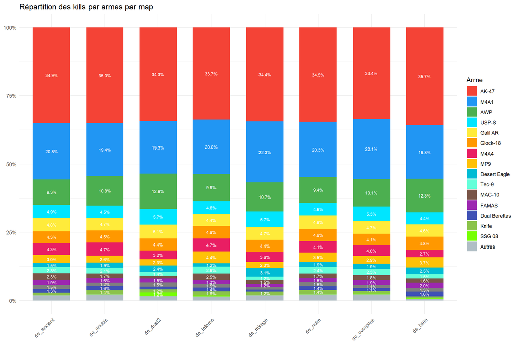

On peut déjà remarquer que le SSG 08 se démarque aussi dans les kills sur la carte dust2, ce qui prouve que ce choix d’achat s’avère être une bonne stratégie sur cette carte. Une autre observation marquante est que les armes Five-SeveN et P250 ne sont pas présentes sur la visualisation, car elles font moins d’1% des kills. Cependant, le Five-SeveN est acheté environ 5% du temps ! On peut donc se demander s’il est rentable d’acheter cette arme. De plus, des armes qui n’étaient pas présentes sur le précédent graphique ont fait leur apparition, comme le couteau ou le Glock, mais surtout l’USP-S et les Dual Berettas, dont l’USP-S qui est présente sur environ 5% des kills.

## Courir ou s’arrêter : le “run and gun” est-il efficace ?

Tirer en se déplaçant dégrade la précision dans CS2, mais cette pénalité varie selon l’arme. On cherche à savoir pour quelles armes le “run and gun” reste viable. On s’attend à ce que les fusils lourds (AK-47, AWP) deviennent inutilisables en mouvement, tandis que les armes de close (MAC-10, Glock-18) restent efficaces. On a décidé de fixer le seuil à 90 unités de vitesse entre immobile et mobile.

**Données utilisées** : tables `shots` et `damages`, colonnes `weapon_name`, `player_velocity_x/y`, `tick`.

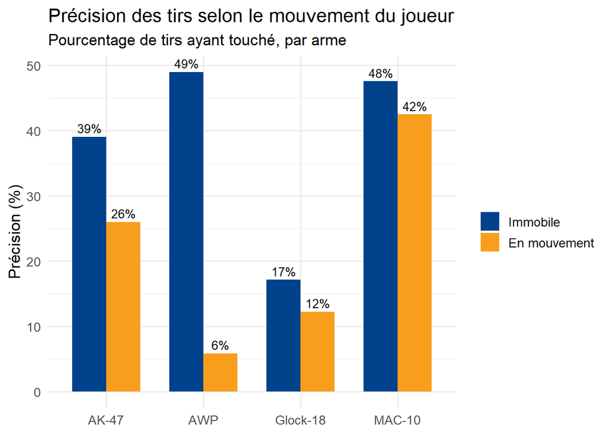

```sql
SELECT
  LOWER(s.weapon_name) AS arme,
  CASE WHEN sqrt(POWER(s.player_velocity_x,2)+ POWER(s.player_velocity_y,2)) < 90
       THEN 'Immobile' ELSE 'En mouvement' END AS etat,
  COUNT(*) AS nb_tirs,
  COUNT(d.id) AS nb_touches
FROM shots s
LEFT JOIN damages d
  ON d.match_checksum = s.match_checksum
  AND d.round_number = s.round_number
  AND d.attacker_steam_id = s.player_steam_id
  AND ABS(d.tick - s.tick) <= 8
WHERE s.weapon_name IN ('AK-47','AWP','MAC-10','Glock-18')
  AND s.player_velocity_x IS NOT NULL
GROUP BY 1, 2;
```

**Interprétation.** On peut voir que les armes lourdes chutent fortement en mouvement : l’AK-47 perd un tiers de sa précision et l’AWP s’effondre. Les armes de close encaissent cependant bien mieux : la MAC-10 reste pleinement utilisable en courant. La viabilité du run and gun dépend donc entièrement de l’arme.

## Quand tue-t-on dans le round, selon l’arme ?

On se demande maintenant si l’arme détermine aussi le moment du kill. On s’attend à ce que les armes utilisées en rush (MP9, MAC-10) tuent tôt, et que les armes de full buy (AK-47, AWP, M4) soient présentes tout le round.

**Données utilisées** : tables `kills`, `rounds`, `demos`, colonnes `tick`, `freeze_time_end_tick`, `tickrate`.

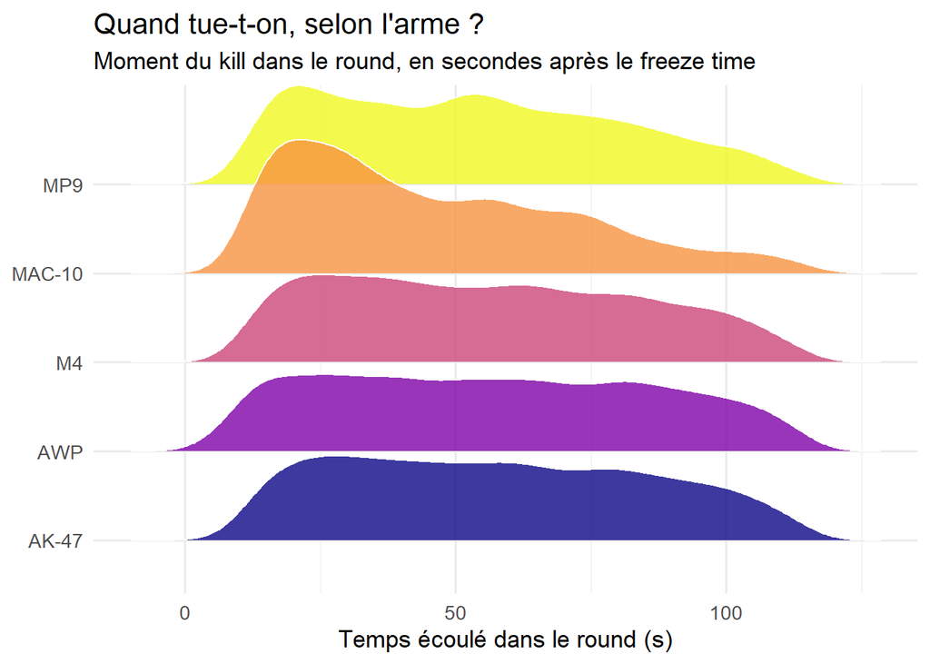

```sql
SELECT LOWER(k.weapon_name) AS arme,
    (k.tick - r.freeze_time_end_tick) / d.tickrate AS temps_kill
FROM kills k
JOIN rounds r ON k.match_checksum = r.match_checksum AND k.round_number = r.number
JOIN demos d ON k.match_checksum = d.checksum
WHERE LOWER(k.weapon_name) IN ('ak-47','m4a1','awp','mp9','mac-10')
  AND k.tick >= r.freeze_time_end_tick
  AND (k.tick - r.freeze_time_end_tick) / d.tickrate < 115;
```

**Interprétation.** Les distributions confirment l’intuition. Les pistolets MP9, MAC-10 présentent un pic tôt, vers quinze à vingt-cinq secondes. L’AK-47 et l’AWP, à l’inverse, affichent des courbes étalées et presque plates sur tout le round.

## Quelle est la probabilité de gagner un clutch selon le désavantage numérique ?

On cherche à savoir, dans des situations défavorables où un joueur se retrouve seul survivant dans son équipe, quelles sont les chances de gagner le round selon le nombre d’adversaires restants. On s’attend à ce que la probabilité de gagner baisse plus le nombre d’adversaires augmente. On utilise la table `clutches`, en croisant `opponent_count` (nombre d’adversaires au début du clutch) et `won` (booléen indiquant si le clutch a été remporté). Chaque entrée correspond à un clutch unique : un 1v3 reste un 1v3 même si le joueur finit par éliminer deux adversaires avant de perdre.

**Données utilisées** : table `clutches`, colonnes `opponent_count` et `won`.

```sql
SELECT opponent_count, won
FROM clutches
WHERE opponent_count <= 5
```

[figure not shown]

**Interprétation.** Le graphique répond clairement à la question : on observe une chute drastique du taux de victoire à mesure que le désavantage augmente. Le 1v1 (58%) mérite une attention particulière, car on pourrait s’attendre à un taux plus proche de 50%. Cela peut s’expliquer par le fait que, pour qu’une telle situation soit enregistrée comme un clutch 1v1, l’adversaire a nécessairement survécu à un clutch adverse juste avant (1v2, 1v3…), et arrive donc potentiellement affaibli, mal positionné ou à court de ressources.

On peut aussi être surpris par un taux aussi faible dès le 1v3, ce qui peut s’expliquer par le fait que les données ne concernent que le pro play, où l’on choisit plus souvent d’économiser dans ces situations. Cette visualisation permet donc de mesurer à quel point un clutch en 1v3, 1v4 ou 1v5 représente un exploit statistique. Ces taux sont toutefois à nuancer : la table enregistre également les situations où le joueur a délibérément choisi de sauvegarder son équipement sans combattre, comptabilisées comme un clutch perdu. Les vrais taux de réussite lorsqu’un joueur tente réellement le clutch sont donc probablement plus élevés que ce que le graphique indique.

# IV - On s’amuse

Pour clore l’exploration, nous mettons à l’épreuve quelques croyances bien ancrées chez les joueurs : sacrifier un poulet sur Inferno porte-t-il chance, les messages échangés dans le chat influencent-ils le résultat, et les joueurs de Counter-Strike sont-ils finalement polis.

## Tuer un poulet sur Inferno est-il corrélé à la victoire du round ?

**Attendu des résultats.** On peut s’attendre à ce que la mort d’un poulet n’ait pas d’impact significatif sur l’issue du round, les poulets étant des éléments purement esthétiques de la carte Inferno.

**Récupération des données.** Pour répondre à cette question, on filtre les données sur la carte de_inferno, on joint la table chicken_deaths aux rounds correspondants via match_checksum et round_number, puis on regarde le winner_side associé.

```sql
SELECT
rounds.match_checksum,
rounds.number AS round_number,
CASE rounds.winner_side
WHEN 2 THEN 'CT'
WHEN 3 THEN 'T'
ELSE 'Unknown'
END AS camp_vainqueur,
COUNT(chicken_deaths.killer_entity_id) AS nb_poulets_tues
FROM rounds
INNER JOIN demos
ON rounds.match_checksum = demos.checksum
AND demos.map_name = 'de_inferno'
LEFT JOIN chicken_deaths
ON rounds.match_checksum = chicken_deaths.match_checksum
AND rounds.number = chicken_deaths.round_number
GROUP BY
rounds.match_checksum,
rounds.number,
rounds.winner_side
ORDER BY rounds.match_checksum, rounds.number;
```

Le résultat est une table de 4 colonnes (match_checksum, round_number, camp_vainqueur, nb_poulets_tues) où chaque ligne représente un round joué sur Inferno avec le nombre de poulets tués et le camp vainqueur associé.

**Conclusion.** Contrairement aux analyses précédentes réalisées sur RStudio, cette visualisation a été faite avec Power BI. Cela permet une manipulation interactive des données à travers la visualisation : il est possible de filtrer dynamiquement par nombre de poulets tués, ou par partie, sans avoir à relancer du code et générer un autre graphique.

En contrepartie, Power BI demande davantage de manipulations pour la mise en forme, avec des placements d’options peu intuitifs si l’on n’y est pas initié, là où quelques lignes suffisent à produire un graphique propre et compréhensible avec R. Power BI reste néanmoins plus accessible pour un utilisateur non-développeur par son absence de code.

En ce qui concerne la tuerie des poulets sur Inferno, l’absence de résultat concret nous permet de dire que cela relève seulement d’une envie soudaine des joueurs pour le meurtre de cet animal, sans impact ni corrélation avec leur capacité de réussir ou non un round.

## Est-ce que les messages dans le chat ont une influence sur la partie ?

Dans les jeux compétitifs comme *Counter-Strike*, la communication est souvent perçue comme un facteur clé de la victoire. Pourtant, d’un point de vue pragmatique, les messages textuels envoyés dans le chat (comme un simple *“ez”* ou *“gg”*) relèvent davantage de l’expression d’émotions ou de la mise en avant de l’ego d’un joueur que d’une stratégie impactant directement le déroulement de la partie. Notre hypothèse initiale est donc qu’il n’existe aucune corrélation entre l’envoi de messages et l’issue des matchs.

Pour vérifier cela, nous allons analyser les messages, leur fréquence, leur contenu et leur timing, en les croisant avec les résultats des parties. Notre analyse s’appuie sur les tables `demos`, `matches`, `messages` et `players`.

### Analyse de la situation

Avant de commencer notre analyse, il est nécessaire de nettoyer les données pour éviter les biais. En examinant la table `matches`, nous avons identifié 7 matchs sans vainqueur déclaré. Ces cas, probablement dus à des matchs nuls, des bugs ou des annulations, pourraient fausser nos résultats.

```
##   winner_name n
## 1             7
```

### Les messages sont-ils liés au nombre de parties jouées ?

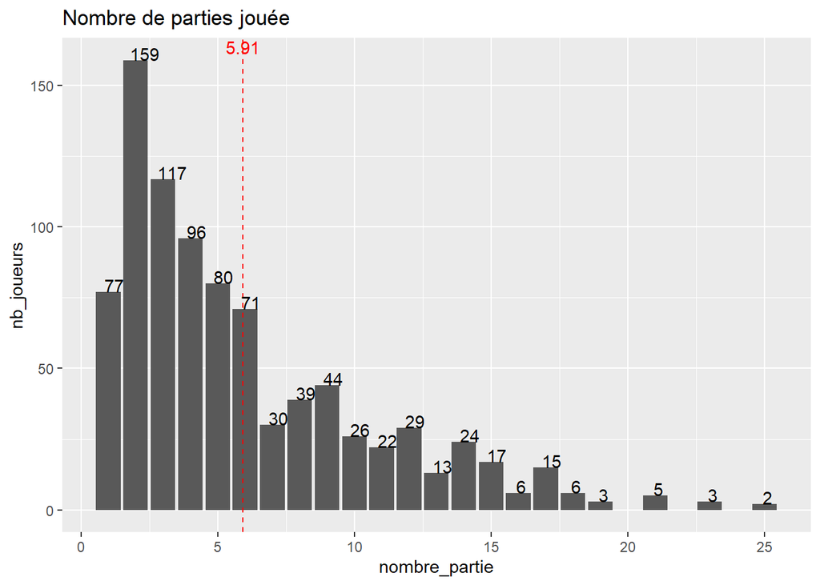

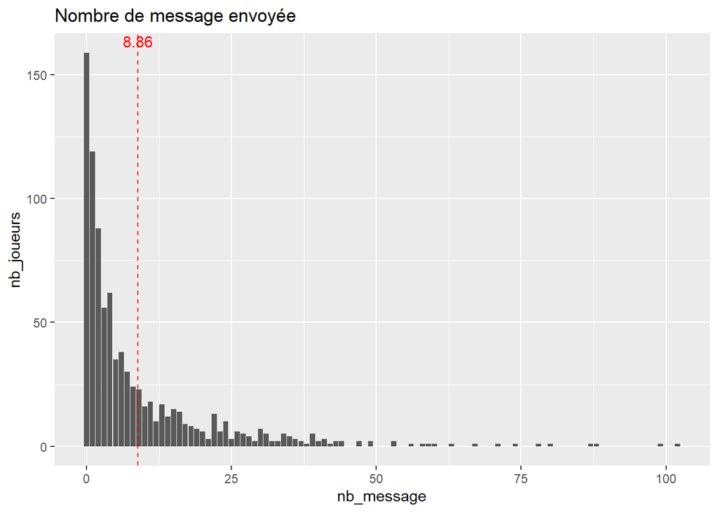

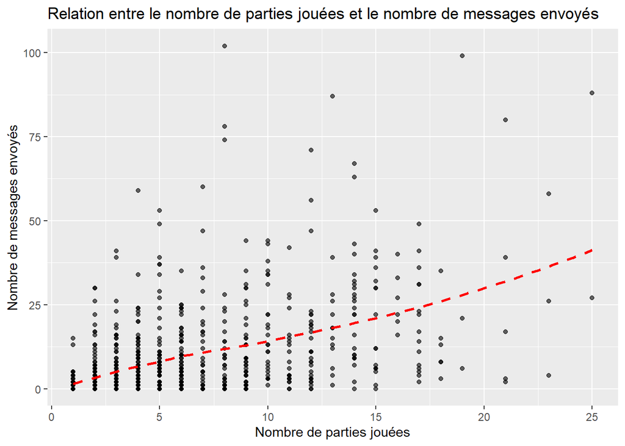

Les données révèlent que la majorité des joueurs participent à un nombre limité de matchs, avec une moyenne de 6 parties par joueur (explicable par notre échantillonnage). De même, la distribution des messages montre que la plupart des joueurs en envoient peu ou pas du tout, avec une moyenne de 9 messages par joueur. Donc l’envoi de messages n’est pas une activité systématique, mais plutôt occasionnelle. Cependant comme on peut s’y attendre, plus un joueur joue de parties, plus il est susceptible d’envoyer des messages, comme le suggère le dernier graphique.

### L’envoi de messages influence-t-il l’issue des matchs ?

On peut se demander si envoyer simplement des messages (peu importe le contenu) n’est pas un indicateur de l’issue d’un match. On pourrait s’attendre à ce que l’envoi d’un message perturbe la concentration d’un joueur et conduise, au fur et à mesure, à une perte d’efficacité, et donc à la perte du match. Pour vérifier cela, nous avons croisé les données de messages avec les résultats des parties.

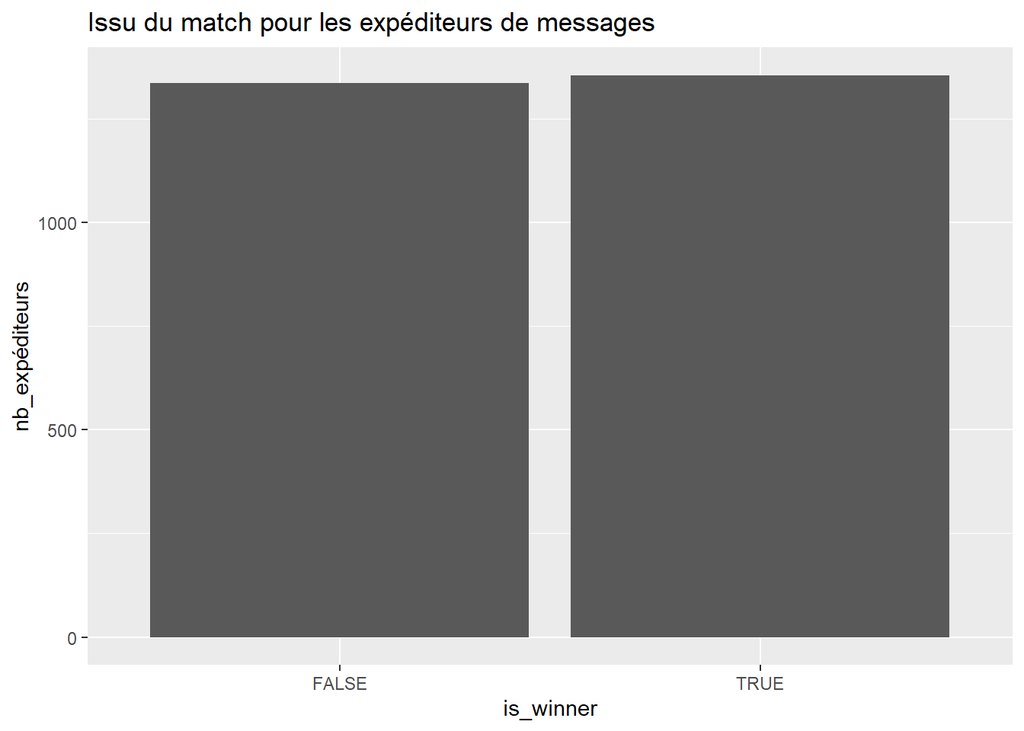

Ici, nous avons une répartition équilibrée entre les deux issues. Donc, les joueurs qui envoient des messages ne semblent ni plus ni moins susceptibles de gagner. Cette absence de déséquilibre suggère que le simple fait d’envoyer un message, quel qu’en soit le contenu, n’a pas d’influence sur le résultat final.

Pour affiner cette analyse, nous allons calculer le ratio de victoire moyen en fonction du nombre de messages envoyés par joueur. On s’attend à obtenir une moyenne similaire au taux de winrate global, donc environ 50 %.

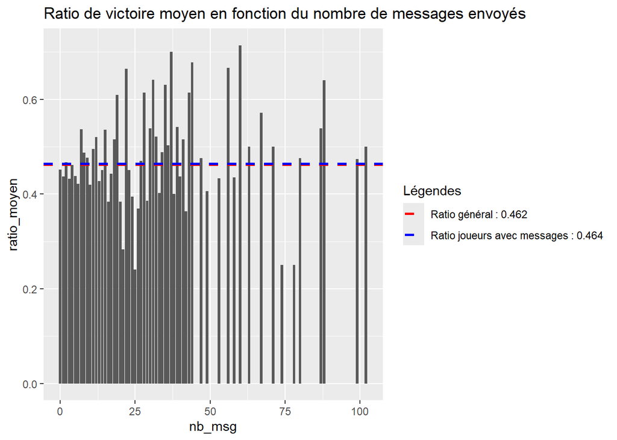

### Quand est-ce que les joueurs envoient des messages ?

Avant toute chose, il est intéressant de connaître la durée moyenne d’un match, afin d’établir ensuite les différentes périodes d’une partie.

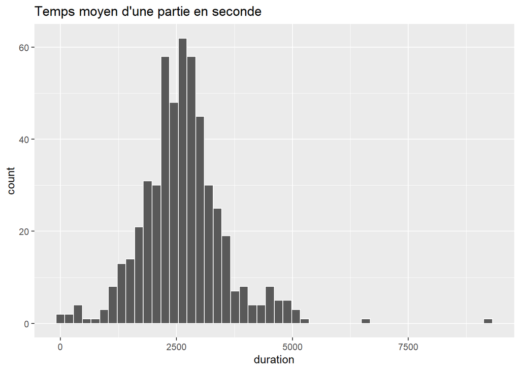

On observe qu’en moyenne une partie dure 40 min (2500/60). On propose alors une analyse de la période d’envoi des messages, dont les limites sont choisies arbitrairement. *Il est à la discrétion du lecteur de se tourner vers la Shiny app proposée afin de modifier dynamiquement ces limites et d’observer leur impact.* Ici, on choisit 10 min après le début et 10 min avant la fin. On s’attend à observer des messages au début et à la fin, mais peu pendant la partie.

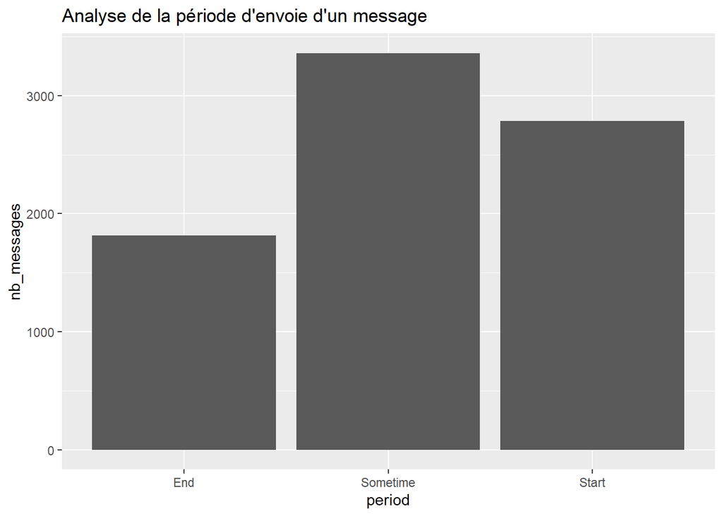

Contrairement à notre hypothèse initiale, les messages sont majoritairement envoyés entre le début et le milieu de partie, avec une dominance du milieu de match.

### Quels sont les messages les plus envoyés ?

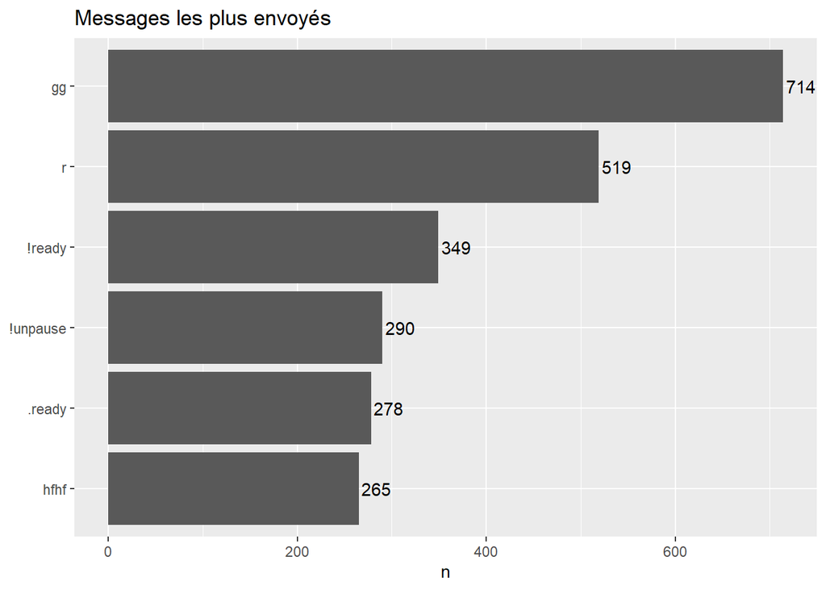

On remarque que « gg » est le message le plus envoyé. À partir de ce constat, nous allons réaliser la même étude en nous concentrant uniquement sur ce type de message. On s’attend à ce que celui-ci soit un marqueur de la politesse et de la bienveillance des joueurs.

### Analyse des “gg”

Ici, nous proposons une analyse des messages contenant « gg ». *Il est à la discrétion du lecteur de se tourner vers la Shiny app proposée afin de modifier dynamiquement ces filtres et de tirer ses propres conclusions.*

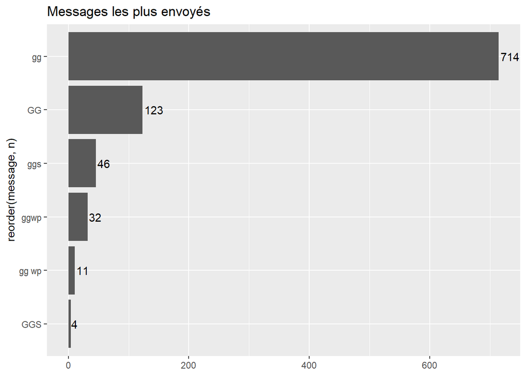

On observe, avec le filtre, une dominance de « gg » et de quelques dérivés, qui ne seront pas significatifs dans notre analyse.

### L’issue du match conditionne-t-elle l’envoi du message ?

On s’attend à ce qu’en cas de défaite, les joueurs soient moins enclins à envoyer « gg ».

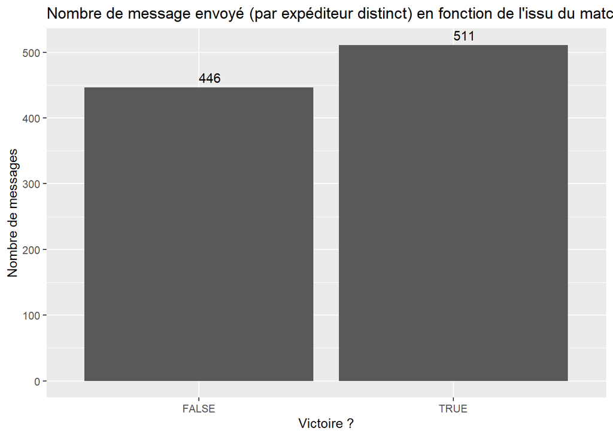

On remarque que l’issue du match ne conditionne pas l’envoi du mot « gg ». Nous allons tout de même vérifier les ratios moyens afin de nous en assurer.

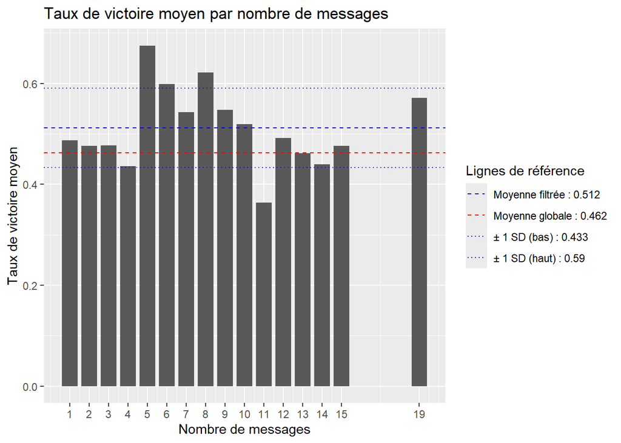

On s’attendait en effet à ce résultat. Malgré une moyenne supérieure, en raison de l’écart-type, il n’est pas possible de conclure à un effet positif de l’envoi d’un « gg ». D’autant plus que nous n’avons pas pris en compte le moment d’envoi de ce message. En effet, envoyé en fin de partie, il ne peut pas conférer d’avantage sur la partie en cours, mais éventuellement sur la suivante. Analysons donc le moment auquel le message est envoyé. (On prend 5 min avant la fin et 3 min après le début.)

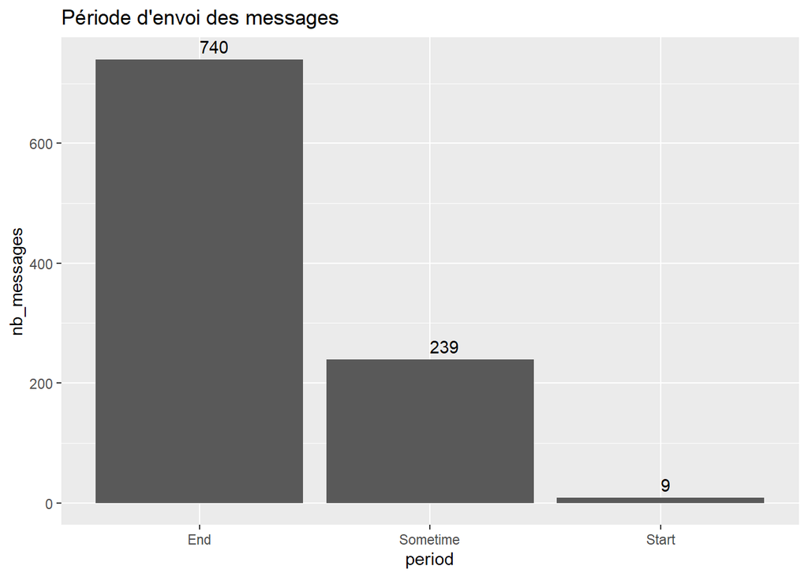

On observe en effet que « gg » est principalement envoyé en fin de match. Il ne peut donc pas être un indicateur de réussite d’une partie en cours. Avec davantage de données, il serait possible d’approfondir cette analyse en étudiant, par exemple, l’évolution du winrate des joueurs avant et après l’envoi d’un message filtré.

Cependant, une telle analyse n’est pas réalisable dans l’état actuel du jeu de données. Nous disposons de 370 parties différentes concernant les « gg », pour un total de 522 parties distinctes. Il reste 185 parties exploitables, sachant que 366 joueurs différents ont envoyé « gg ».

Dans ces conditions, nous ne pouvons pas conclure de manière fiable, le manque de données limitant fortement la robustesse des résultats. Une augmentation du dataset serait nécessaire pour mener une analyse pertinente et statistiquement solide.

### Est-ce que les joueurs de CS sont polis ?

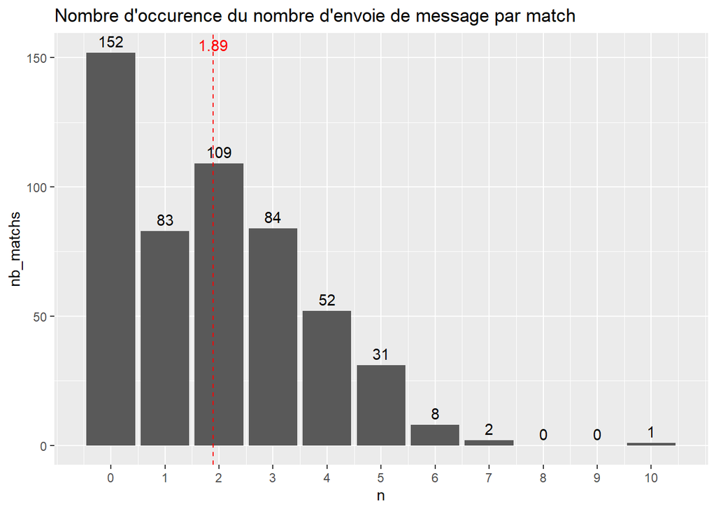

On remarque qu’en moyenne, deux messages de type « gg » sont envoyés par match. Observons si ceux-ci sont suivis d’une réponse ou non.

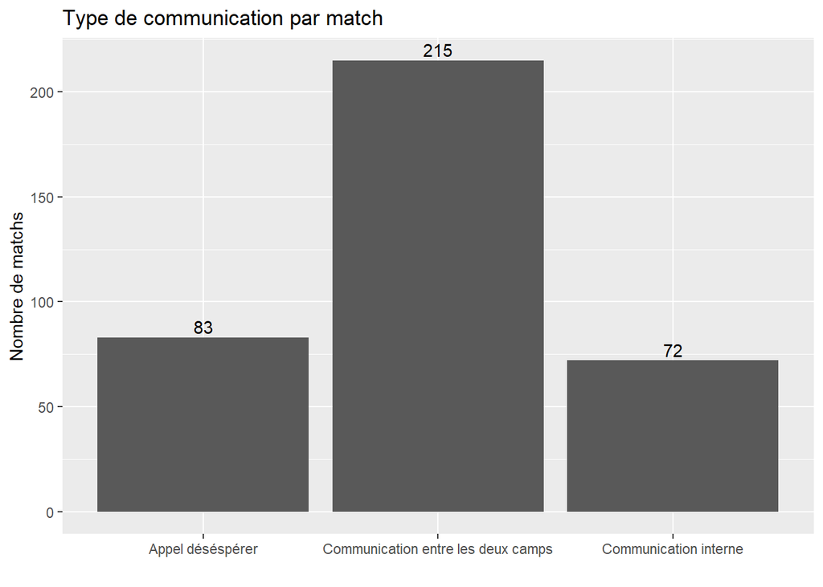

On remarque que la majorité des « gg » sont suivis d’une réponse du camp adverse. Peut-on en déduire que l’absence de réponse provient du fait que certains joueurs seraient de mauvais perdants ?

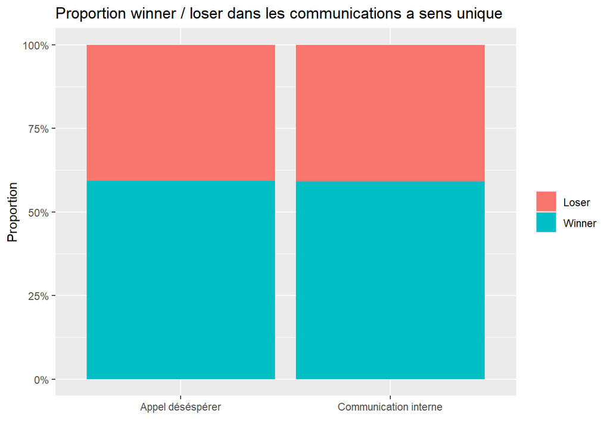

On observe un ratio d’environ 60/40 en faveur des gagnants, mais cela ne permet pas de conclure que les joueurs de CS sont de mauvais perdants. Au contraire, dans la majorité des cas, un « gg » envoyé par une équipe semble appeler un « gg » en retour de l’équipe adverse, ce qui peut être interprété comme un signe de fair-play.

Toutefois, il convient de nuancer fortement cette interprétation : le jeu de données n’est probablement pas suffisamment large ni représentatif pour capturer l’ensemble des comportements. Et, toute chose considérée, il ne couvre sans doute pas tout le champ lexical des insultes russes, qui pourraient “éventuellement” dominer les échanges dans d’autres conditions d’observation.

**Conclusion (messages).** L’analyse des messages échangés dans le chat pendant les matchs de Counter-Strike nous a permis de répondre à une question centrale : les messages textuels ont-ils une influence sur l’issue des parties ? Les résultats obtenus montrent de manière claire et cohérente que l’envoi de messages, quels que soient leur fréquence, leur contenu ou leur timing, n’a aucun impact mesurable sur le résultat des matchs.

Par ailleurs, l’étude du timing des messages révèle qu’ils sont principalement concentrés en début et en milieu de match, avec une dominance pour le milieu de partie, ce qui contredit l’hypothèse initiale selon laquelle les messages seraient surtout envoyés en fin de match.

Enfin, l’analyse des communications avec les “gg” montre que, dans la majorité des cas, un “gg” envoyé par une équipe appelle un “gg” en retour de l’équipe adverse, ce qui suggère un comportement globalement fair-play parmi les joueurs.

# Conclusion

## En résumé

À travers cette base de données, nous avons pu examiner les différents aspects qui composent le jeu Counter-Strike 2. Par l’analyse des pratiques des joueurs, sur les clutch et le pistol round, ou encore leurs préférences d’armes et d’utilisation de la bombe, nous avons pu comprendre à quoi correspondait un profil de joueur moyen (professionnel) dans ses choix, ses capacités et l’impact de ces derniers. Également la diversité que renferme le jeu, notamment sur les choix des armes et grenades durant les parties, et celles qui sont les plus mortelles. Cette étude permet, par ailleurs, de constater que le jeu est très équilibré, que les camps de Terroristes et de Contre-Terroristes se trouvent avec une égalité de chances de victoire, même s’il existe une légère tendance pour un camp ou pour l’autre suivant les cartes. Un travail plus centré sur Mirage met en avant la complexité des cartes, avec les nombreuses lignes de tir possibles et différentes localisations des tueurs et tués. Notre panel de Dataviz est large et couvre même des pratiques moins concrètes comme la superstition liée aux poulets de la carte Inferno ou les pratiques écrites des joueurs.

Nous avons pu réaliser ces graphiques à partir d’un échantillon de 522 matchs, avec des données sur 8 cartes différentes. Cette large base permet donc de considérer que nos graphiques sont suffisamment représentatifs pour être considérés comme fiables, sauf pour la carte Train avec uniquement 10 entrées, ce qui est trop peu. Un projet de plus grande ampleur est totalement faisable et serait très intéressant pour approfondir les recherches d’informations et de schémas sur le jeu, avec une base de données encore plus grande pour obtenir la plus haute fiabilité possible.

Deux logiciels ont été manipulés : RStudio pour la grande majorité des réalisations de Dataviz, ainsi que la Shiny App pour laquelle on code nos instructions pour les graphiques en R ; et en second Power BI, application où l’on vient sélectionner les options de représentation et d’ajustement jusqu’à obtenir notre graphique final.

## Un mot de chaque membre

**Pierre :** Ce projet m’a particulièrement passionné, de la mise en place du pipeline à la conception des algorithmes de machine learning, jusqu’à l’analyse des résultats pour en tirer des conclusions pertinentes. J’ai trouvé cette expérience extrêmement enrichissante, et j’aurais aimé pouvoir approfondir davantage l’exploration de ces données. Les perspectives offertes par ce type de dataset sont immenses : on pourrait, par exemple, entraîner des algorithmes pour développer des bots performants ou concevoir des générateurs de stratégies en temps réel. Cependant, pour aller plus loin, il serait essentiel d’enrichir le dataset avec des données supplémentaires (historique plus long, variables externes, etc.) afin de dégager de vraies tendances et non plus des conjectures. Cette approche permettrait de valider plus robustement les hypothèses et d’ouvrir la voie à des applications plus ambitieuses. Enfin, ce projet m’a permis de manipuler un volume important de données, une expérience que j’ai grandement appréciée et qui a renforcé mon intérêt pour le big data, l’analyse prédictive et l’intelligence artificielle.

**Emeline :** J’ai énormément apprécié travailler sur ce projet, avec la manipulation d’une base de données aussi large qui est une première, ainsi que sur RStudio et Power BI. Cela m’a permis de découvrir le fonctionnement concret de la dataviz, et la nécessité de prévoir la visualisation que l’on souhaite réaliser, même en ignorant le résultat, pour ne pas se perdre dans les possibilités presque infinies qui s’offrent à nous, surtout pour Power BI. J’aurais apprécié d’avoir une partie explicative pour nous aider à comprendre comment récupérer des données sur le sujet de notre choix, de manière générale, avec différents outils que l’on peut utiliser ; ce serait le seul aspect qu’il me manque sur le projet.

**Nicolas :** Ce qui m’a marqué, c’est l’importance du travail en amont pour fournir à la visualisation des données propres, cohérentes avec le message que l’on veut faire passer.

**Magdalena :** Ce que j’ai le plus aimé dans ce projet, c’est d’avoir un dataset aussi riche à explorer : en tant que joueuse, c’était passionnant de pouvoir formuler mes propres questions sur le jeu et d’aller y chercher des réponses dans les données. La partie R a été plus difficile pour moi, mais c’est justement ce qui m’a fait progresser, et je ressors de ce projet avec une bien meilleure aisance sur la manipulation et la visualisation de données. Avec un dataset pareil, on s’est peut-être même un peu perdus tant on a multiplié les questions, et avec du recul j’aurais aimé avoir le temps d’en creuser certaines davantage ou mieux structurer nos recherches plutôt que d’en survoler autant.

# Annexe

## Répartition du travail

En ce qui concerne la partie Exploration de la base de données, nous avons opté pour faire entre 3 et 4 questions chacun, au choix et en fonction de nos affinités avec les questions.

**Pierre :**

- Est-ce qu’une carte favorise un camp par rapport à l’autre ?
- Est-ce que les messages dans le chat ont une influence sur la partie ?

**Emeline :**

- La grenade est-elle plus utilisée par les Terroristes ou les Contre-Terroristes ?
- Sur chaque carte, quel site mène le plus souvent à la victoire des Terroristes ?
- Tuer un poulet sur Inferno est-il corrélé à la victoire du round ?

**Nicolas :**

- La pose d’une smoke sur une bombe augmente-t-elle la probabilité de victoire des Terroristes ?
- Le premier kill d’un round est-il décisif ?
- Quelles sont les armes les plus utilisées ?

**Magdalena :**

- Le pistol round confère-t-il un avantage durable ?
- Quel côté (T ou CT) a un avantage structurel selon les maps ?
- Courir ou s’arrêter : le “run and gun” est-il efficace ?
- Quand tue-t-on dans le round, selon l’arme ?
- Quelle est la probabilité de gagner un clutch selon le désavantage numérique (1v5, 1v4, etc.) ?

La réalisation des différents rendus (présentation, rapports, etc.) a été faite par le groupe Long, sans répartition particulière.

## Glossaire

- **Traded** : Un joueur est considéré comme “tradé” lorsqu’il meurt, mais qu’un coéquipier élimine immédiatement son tueur.
- **Tick** : L’unité de mesure de la fréquence de rafraîchissement du serveur. Le serveur met à jour l’état du jeu (position des joueurs, tirs, etc.) à un intervalle régulier.
- **Frame** : Une image unique affichée par l’écran.
- **Decoy** : Une grenade leurre.
- **Clutch** : Une situation de jeu où un joueur se retrouve seul face à plusieurs adversaires. Réussir le “clutch” signifie remporter la manche malgré l’infériorité numérique.
- **Pistol Round** : Le tout premier round de chaque mi-temps (round 1 et round 13). Tout le monde commence avec 800$ et uniquement des pistolets. La victoire ici est cruciale car elle donne un avantage financier immédiat pour les rounds suivants.
- **Eco (Economy Round)** : Un round où l’équipe dépense le moins d’argent possible (souvent 0$) afin d’économiser pour le round suivant. Le but est de pouvoir acheter un équipement complet (fusils, grenades, kevlar) plus tard.
- **Full Eco** : Identique à l’Eco, mais plus strict. Les joueurs n’achètent absolument rien, pas même un pistolet, afin de garantir une accumulation maximale de fonds pour le round d’après.
- **Full Buy** : L’opposé de l’Eco. L’équipe dépense une grande partie de son argent pour s’équiper au mieux : fusil d’assaut principal (AK-47 ou M4), kevlar + casque, et une série complète de grenades.
- **Force-buy** : Une situation où l’équipe décide d’acheter tout ce qu’elle peut, même si le budget est incomplet, pour tenter de gagner un round important alors que les finances sont fragiles. C’est un pari risqué pour tenter de briser l’économie adverse.